# Week 5: Data visualisation

Tristan Muno

October 7, 2026

## Week 5 goals

By the end of today, you will be able to:

1. Explain the layered grammar of graphics and build a `ggplot2` figure from data, aesthetics and geoms.
2. Choose a fitting chart for one, two, and three or more variables.
3. Encode more variables with aesthetics and small multiples.
4. Style a figure for a reader: labels, themes, colour palettes and annotation.
5. Recognise common visualisation pitfalls and fix them.

## Today

1. **Before we start:** two reminders
2. **The grammar of graphics:** one plot, layer by layer
3. **One variable:** bar charts, histograms, densities
4. **Two variables:** scatter plots, box plots, line plots
5. **Three and more variables:** colour, size, shape, facets
6. **Styling:** less ink, more information
7. **Common pitfalls:** what is wrong here?

## Where today fits

Today continues **step 2, the data summary**. Last week it was a table, today it is a figure, and in the exam you need both.

Table 1: The 8-step Bayesian workflow. Every homework exercises the steps introduced so far, cumulatively, and the exam runs all eight end to end.

| # | Step | What you produce |
| --- | --- | --- |
| 1 | **Estimand** | The quantity you want to learn about, stated precisely as a target before any model is fitted. |
| 2 | **Data summary** | The data described: measurement, coverage, obvious issues. |
| 3 | **Formal model** | Likelihood and priors written down, the generative model. |
| 4 | **Prior predictive check** | Simulate from the priors, confirm they imply plausible data. |
| 5 | **Fit** | Estimate with `brms`, weakly-informative priors by default. |
| 6a | **MCMC diagnostics** | R-hat, ESS, divergences, trace plots. Did sampling work? |
| 6b | **Posterior predictive check** | Does the fitted model reproduce key features of the data? |
| 7 | **Interpretation** | Answer the estimand on the outcome scale, with uncertainty. |
| 8 | **Limitations** | What the analysis can and cannot support, threats and next steps. |

# Before we start: two reminders

## Positron shortcuts

Table 2: Positron shortcuts worth learning by heart. Every shortcut can be changed under Settings, Keyboard Shortcuts.

| Action | Windows and Linux | Mac |
| --- | --- | --- |
| Run the current line or selection | `Ctrl + Enter` | `Cmd + Enter` |
| Run the current code cell | `Ctrl + Shift + Enter` | `Cmd + Shift + Enter` |
| Insert a code cell | `Ctrl + Shift + I` | `Cmd + Shift + I` |
| Insert the native pipe | `Ctrl + Shift + M` | `Cmd + Shift + M` |
| Insert the assignment `<-` | `Alt + -` | `Option + -` |
| Comment or uncomment | `Ctrl + /` | `Cmd + /` |
| Move a line up or down | `Alt + Up` or `Down` | `Option + Up` or `Down` |
| Select every occurrence | `Ctrl + Shift + L` | `Cmd + Shift + L` |
| Restart R | `Ctrl + Shift + 0` | `Cmd + Shift + 0` |

**Tip**

**Restart R often.** A fresh session forgets every object you created by hand, so it catches a missing step before the render does.

## Quick tables with `janitor`

`janitor` is a small package outside the tidyverse (`install.packages("janitor")`, once), and its `tabyl()` is a fast way to a frequency table.

```r
gapminder_2007 |>
  tabyl(continent) |>
  adorn_totals() |>
  adorn_pct_formatting() |>
  kable(
    col.names = c("Continent", "Count", "Share")
  )
```

Table 3: Countries per continent in 2007, with a totals row. Africa holds over a third of the countries in gapminder, Oceania only two.

| Continent | Count | Share |
| --- | --- | --- |
| Africa | 52 | 36.6% |
| Americas | 25 | 17.6% |
| Asia | 33 | 23.2% |
| Europe | 30 | 21.1% |
| Oceania | 2 | 1.4% |
| Total | 142 | 100.0% |

# The grammar of graphics

## A plot is built in layers

Table 4: The layers of a `ggplot2` figure. The first three are required, the rest refine the figure.

| Layer | The question it answers | Example |
| --- | --- | --- |
| **Data** | Which table? | `gapminder_2007` |
| **Aesthetics** | Which variable goes where? | `aes(x = gdpPercap, y = lifeExp)` |
| **Geoms** | Which marks represent the data? | `geom_point()` |
| **Scales** | How do values become positions and colours? | `scale_x_log10()` |
| **Facets** | Split into small panels? | `facet_wrap(~continent)` |
| **Labels** | What does the reader read? | `labs(title = "...")` |
| **Theme** | How does the non-data ink look? | `theme_classic()` |

This is the **grammar of graphics** (Wilkinson 2005; Wickham 2010): any figure is a combination of these few parts, so learning the parts teaches you every chart.

## The data for today

One row per country, in the latest year of gapminder:

```r
gapminder_2007 <- gapminder |>
  filter(year == 2007)
gapminder_2007
```

```
# A tibble: 142 × 6
  country     continent  year lifeExp      pop gdpPercap
  <fct>       <fct>     <int>   <dbl>    <int>     <dbl>
1 Afghanistan Asia       2007    43.8 31889923      975.
2 Albania     Europe     2007    76.4  3600523     5937.
3 Algeria     Africa     2007    72.3 33333216     6223.
4 Angola      Africa     2007    42.7 12420476     4797.
5 Argentina   Americas   2007    75.3 40301927    12779.
# ℹ 137 more rows
```

Our question for the next hour: **do people in richer countries live longer?**

## Step 1: data, an empty canvas

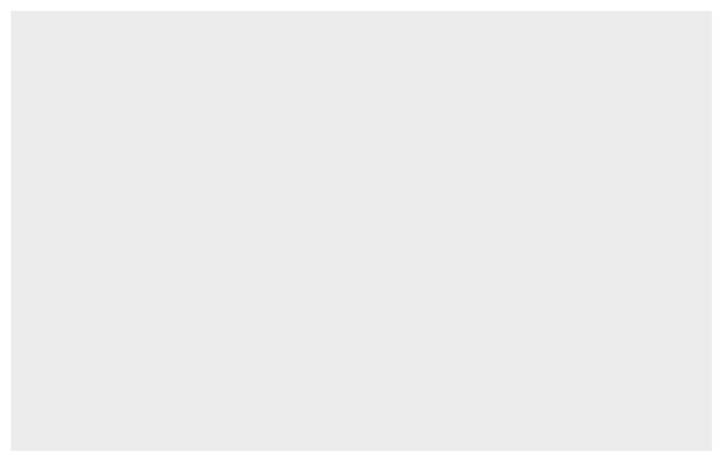

Figure 1: ggplot() with data alone draws an empty grey canvas: it knows the table, but not which variables to show.

```r
gapminder_2007 |>
  ggplot()
```

## Step 2: aesthetics, the axes

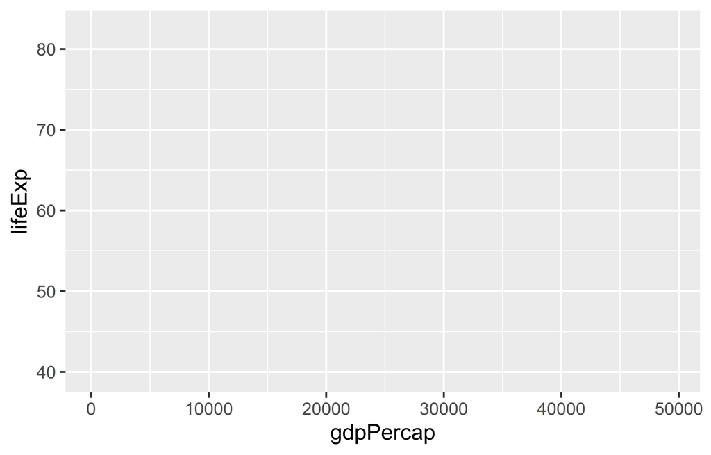

Figure 2: Mapping GDP per capita to x and life expectancy to y draws the axes, but there are still no marks.

```r
gapminder_2007 |>
  ggplot(aes(x = gdpPercap, y = lifeExp))
```

`aes()` maps **variables** to **visual properties**, here the two positions.

## Step 3: a geom, the marks

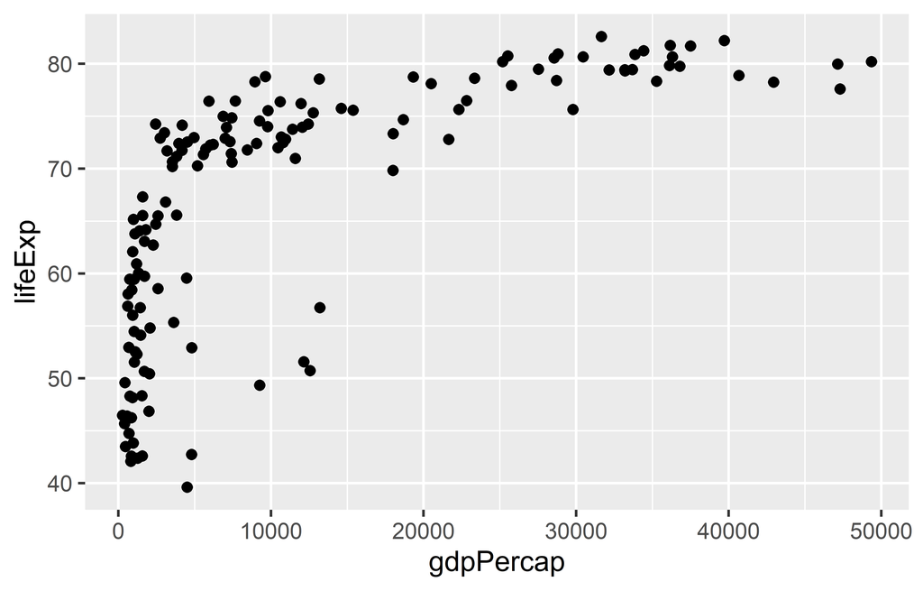

Figure 3: With geom_point(), every country becomes one point: life expectancy rises steeply with income among poor countries and levels off among rich ones.

```r
gapminder_2007 |>
  ggplot(aes(x = gdpPercap, y = lifeExp)) +
  geom_point()
```

The first real plot. Most countries crowd into the left edge.

## Step 4: a scale, the log axis

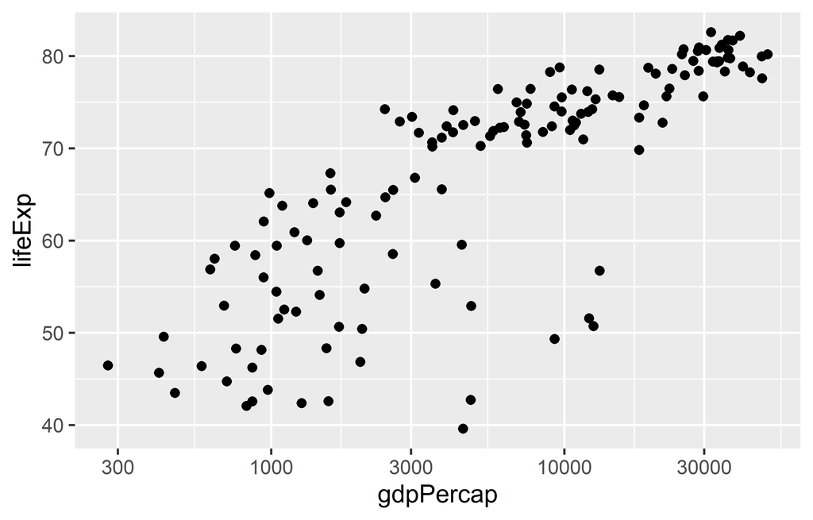

Figure 4: On a log scale for GDP per capita, the crowded left edge spreads out and the relationship looks close to a straight line.

```r
gapminder_2007 |>
  ggplot(aes(x = gdpPercap, y = lifeExp)) +
  geom_point() +
  scale_x_log10()
```

On a log scale, equal steps multiply income. That fits the substance: an extra 1,000 dollars matters far more in Malawi than in Norway.

## `+` adds a layer

- The pipe `|>` carries the **data into** `ggplot()`.
- After that, `+` **stacks layers**: each line adds one thing to the figure.
- The `+` goes at the **end** of a line, never at the start of the next.

```r
gapminder_2007 |>
  ggplot(aes(x = gdpPercap, y = lifeExp)) |>
  geom_point()
```

```
Error in `geom_point()`:
! `mapping` must be created by `aes()`.
ℹ Did you use `%>%` or `|>` instead of `+`?
```

**Warning**

**`|>` after `ggplot()` is an error.** `ggplot2` is older than the pipe, so it chains with `+`, and the error message even tells you so.

## Inside `aes()` or outside?

**Outside:** a fixed value for every point.

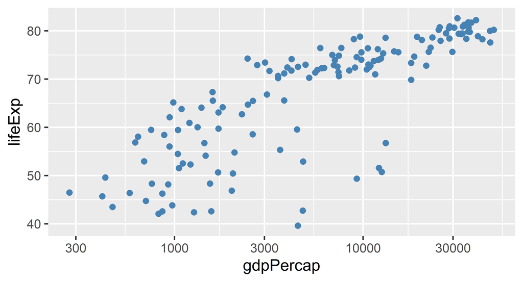

Figure 5: colour set outside aes(): every point is the same blue.

```r
gapminder_2007 |>
  ggplot(aes(x = gdpPercap, y = lifeExp)) +
  geom_point(colour = "steelblue") +
  scale_x_log10()
```

**Inside:** mapped to a variable.

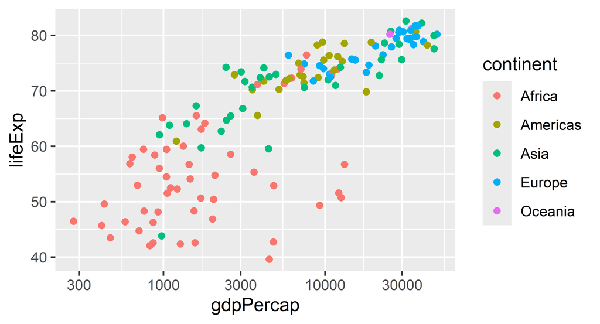

Figure 6: colour mapped inside aes(): each continent gets its own colour, and a legend appears.

```r
gapminder_2007 |>
  ggplot(aes(x = gdpPercap, y = lifeExp,
             colour = continent)) +
  geom_point() +
  scale_x_log10()
```

## Practice: your first plot

**Do this now.**

1. Make a tibble `gapminder_1952` with the year 1952 only.
2. Plot GDP per capita against life expectancy for 1952, with every point in one fixed colour of your choice and a log scale for GDP per capita.
3. Compare with 2007. What changed?
4. **Stretch:** add a layer `geom_smooth()`. What does it draw?

## Practice: your first plot, solution

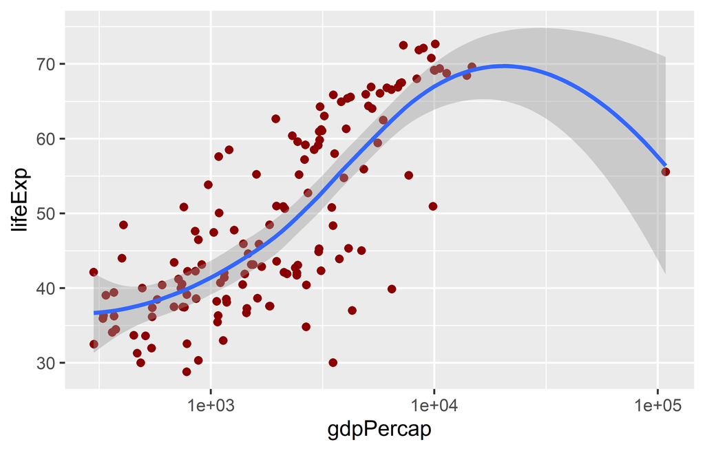

Figure 7: GDP per capita against life expectancy in 1952, with a smooth trend line. The cloud sits far lower and further left than in 2007.

```r
gapminder_1952 <- gapminder |>
  filter(year == 1952)

gapminder_1952 |>
  ggplot(aes(x = gdpPercap, y = lifeExp)) +
  geom_point(colour = "darkred") +
  scale_x_log10() +
  geom_smooth() # stretch
```

The cloud moved **up and to the right**: in 1952 most countries lived below 50 years, in 2007 most above 70. `geom_smooth()` draws a smooth trend, with a grey band for its uncertainty.

# One variable

## Which chart for which variables?

Table 5: Chart choice starts from the variables: how many, and of which type.

| Variables | Chart | Geom |
| --- | --- | --- |
| One categorical | Bar chart | `geom_bar()` |
| One numeric | Histogram, density plot | `geom_histogram()`, `geom_density()` |
| Numeric and numeric | Scatter plot | `geom_point()` |
| Numeric and categorical | Box plot, violin plot | `geom_boxplot()`, `geom_violin()` |
| Numeric over time | Line plot | `geom_line()` |
| A third variable or more | Colour, size, shape, panels | `aes()`, `facet_wrap()` |

**Tip**

**Prefer position and length over angle, area and colour.** People compare positions on a common axis most accurately, and angles, areas and colour shades least accurately (Cleveland and McGill 1984). That ranking is the reason behind most of today’s advice.

## Bar chart: counts of a category

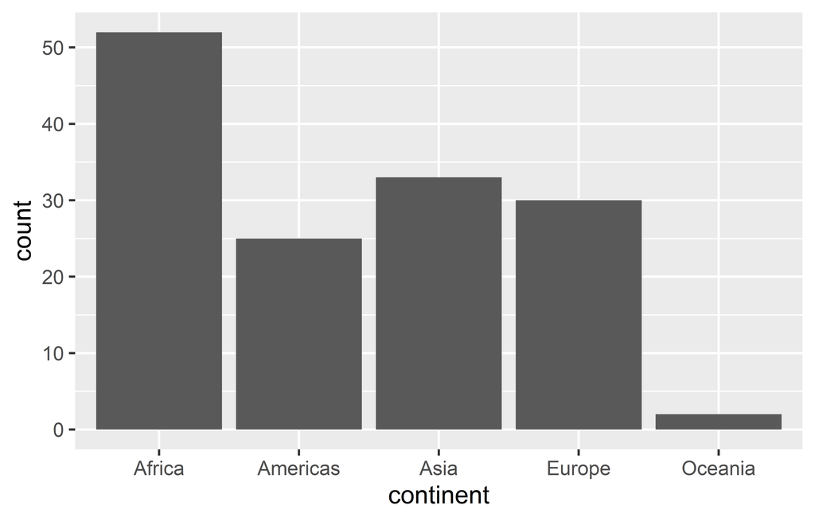

Figure 8: Countries per continent in 2007, in the default alphabetical order of the factor levels.

```r
gapminder_2007 |>
  ggplot(aes(x = continent)) +
  geom_bar()
```

- `geom_bar()` **counts the rows** per category, so there is no `y` in `aes()`.
- Bars show a value by their **length**, so they always start at zero.
- The order is alphabetical. Is that the order a reader needs?

## Order is a decision: factors

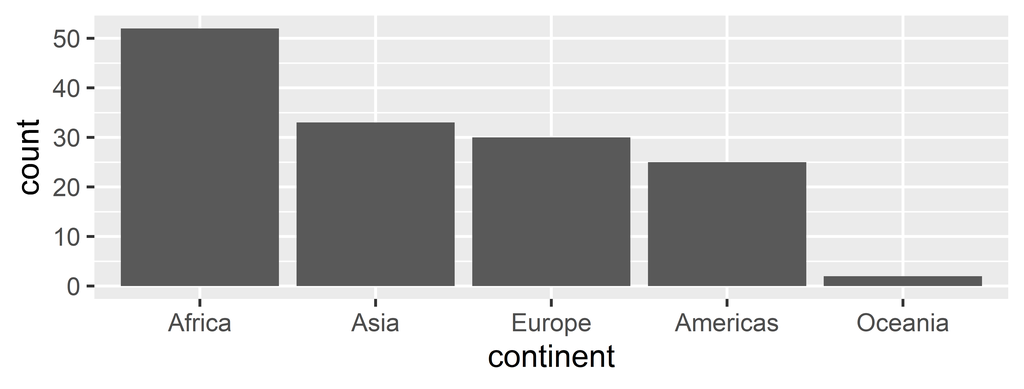

Figure 9: fct_infreq() sorts the counts, most countries first.

```r
gapminder_2007 |>
  mutate(continent = fct_infreq(continent)) |>
  ggplot(aes(x = continent)) +
  geom_bar()
```

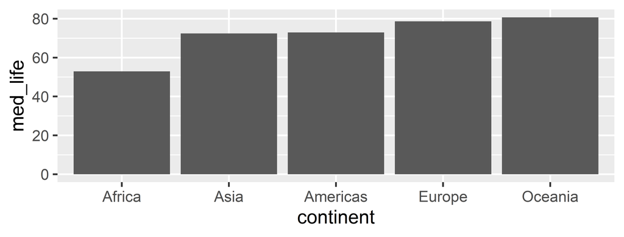

Figure 10: fct_reorder() sorts by a value, here the median life expectancy.

```r
gapminder_2007 |>
  group_by(continent) |>
  summarise(med_life = median(lifeExp)) |>
  mutate(
    continent = fct_reorder(continent, med_life)
  ) |>
  ggplot(aes(x = continent, y = med_life)) +
  geom_col()
```

**Tip**

**Factors set the order of the categories in a plot.** `ggplot2` draws a factor in the order of its levels (week 3), alphabetical by default: change the levels, not the plot.

## Histogram: the shape of a variable

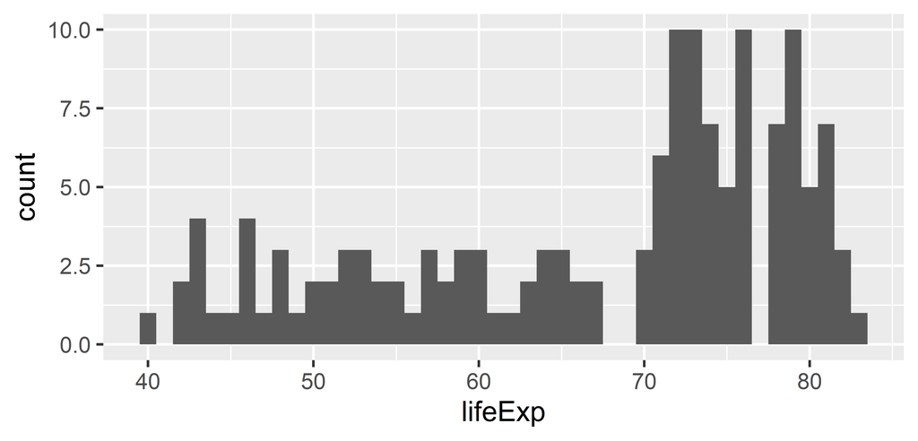

Figure 11: Life expectancy in 2007 in bins of 1 year: noisy, every bin holds only a few countries.

```r
gapminder_2007 |>
  ggplot(aes(x = lifeExp)) +
  geom_histogram(binwidth = 1)
```

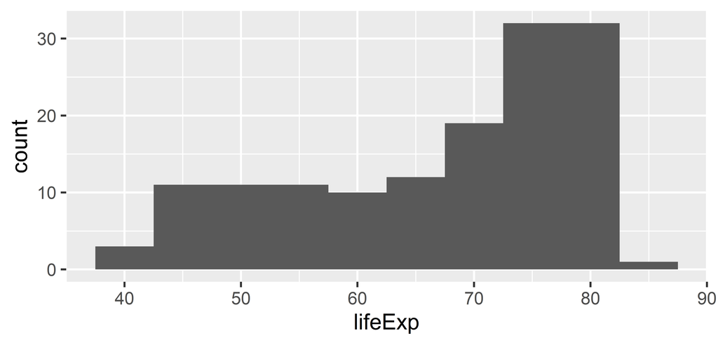

Figure 12: The same data in bins of 5 years: two humps appear, around 50 and around 75 years.

```r
gapminder_2007 |>
  ggplot(aes(x = lifeExp)) +
  geom_histogram(binwidth = 5)
```

A histogram cuts the axis into **bins** and counts the rows in each. The bin width is a decision: try several, and report the one that shows the shape honestly.

## Density plot: the shape, smoothed

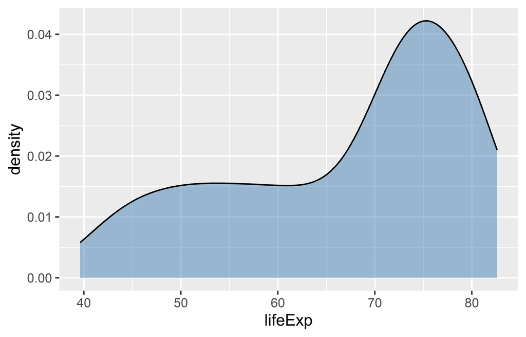

Figure 13: A density plot of life expectancy in 2007, which shows the same two humps as the histogram as one smooth curve.

```r
gapminder_2007 |>
  ggplot(aes(x = lifeExp)) +
  geom_density(fill = "steelblue", alpha = 0.5)
```

- A smooth version of the histogram, and the area under the curve is 1.
- `alpha` sets transparency, from 0 (invisible) to 1 (solid).
- From next week on, a curve like this says **how plausible each value is**.

## Practice: one variable

**Do this now.**

1. Draw a histogram of GDP per capita in 2007. Describe its shape.
2. Add `scale_x_log10()`. How does the shape change?
3. Draw a bar chart of the number of countries per continent in **1952**, sorted from most to fewest.
4. **Stretch:** a density plot of GDP per capita in 2007 on the log scale.

## Practice: one variable, solution

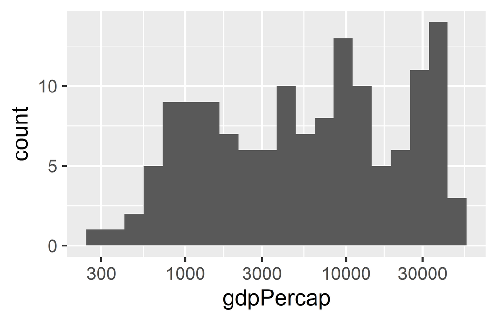

Figure 14: GDP per capita in 2007 on a log scale: a roughly symmetric hump.

```r
gapminder_2007 |>
  ggplot(aes(x = gdpPercap)) +
  geom_histogram(bins = 20) +
  scale_x_log10() # step 2
```

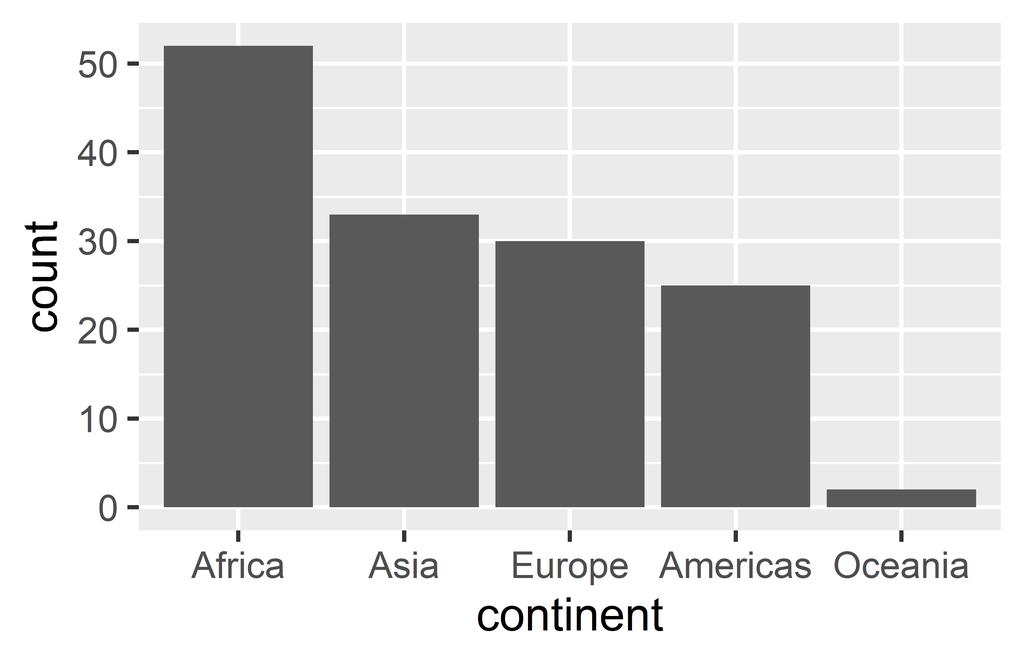

Figure 15: Countries per continent in 1952, sorted, the same counts as in 2007.

```r
gapminder |>
  filter(year == 1952) |>
  mutate(
    continent = fct_infreq(continent)
  ) |>
  ggplot(aes(x = continent)) +
  geom_bar()
```

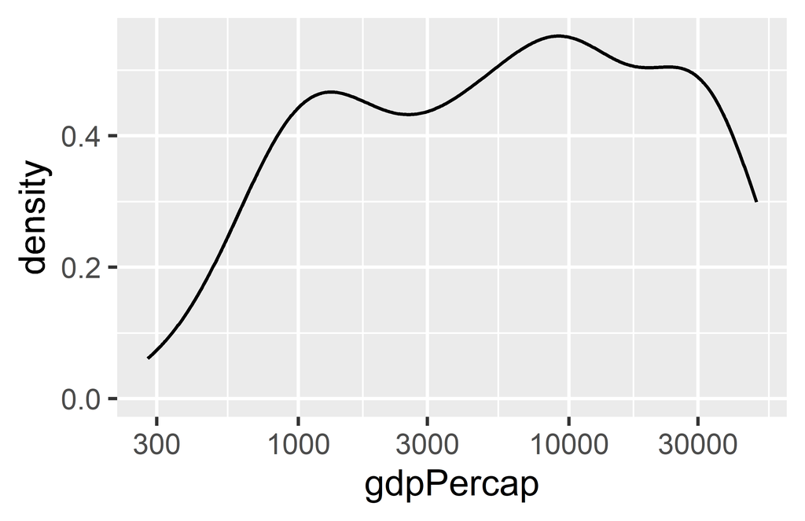

Figure 16: The stretch: a density plot of GDP per capita in 2007 on a log scale.

```r
gapminder_2007 |>
  ggplot(aes(x = gdpPercap)) +
  geom_density() +
  scale_x_log10() # stretch
```

Raw GDP per capita is **right-skewed**: many poor countries and a long tail of rich ones. On the log scale the shape is roughly symmetric, which is why income is so often analysed on a log scale.

# Two variables

## Numeric and numeric: scatter plot

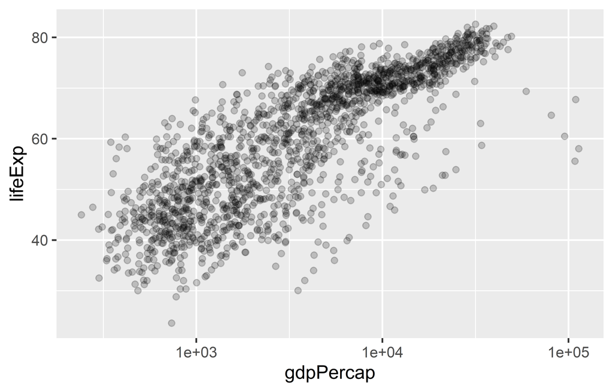

Figure 17: All 1704 country-years of gapminder. With alpha = 0.2, the dense regions show up darker instead of as a solid blob.

```r
gapminder |>
  ggplot(aes(x = gdpPercap, y = lifeExp)) +
  geom_point(alpha = 0.2) +
  scale_x_log10()
```

- Our running example, now for every year at once.
- **Overplotting:** points drawn on top of each other hide how many there are.
- Transparency is the simplest fix: where points overlap, the ink gets darker.

## Numeric and categorical: box plot

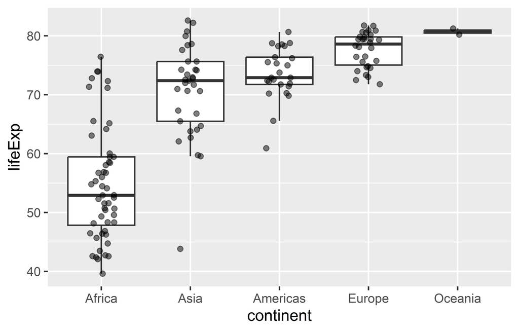

Figure 18: Life expectancy by continent in 2007, ordered by the median. Each box spans the middle half of the countries, and the points show every country.

```r
set.seed(2026) # jitter is random

gapminder_2007 |>
  mutate(
    continent = fct_reorder(continent, lifeExp)
  ) |>
  ggplot(aes(x = continent, y = lifeExp)) +
  geom_boxplot(outliers = FALSE) +
  geom_jitter(width = 0.15, alpha = 0.5)
```

- The line is the **median**, the box holds the **middle half** of the countries.
- With 2 to 52 countries per continent, **show the points**: `geom_jitter()` spreads them sideways.

## The same data as a violin

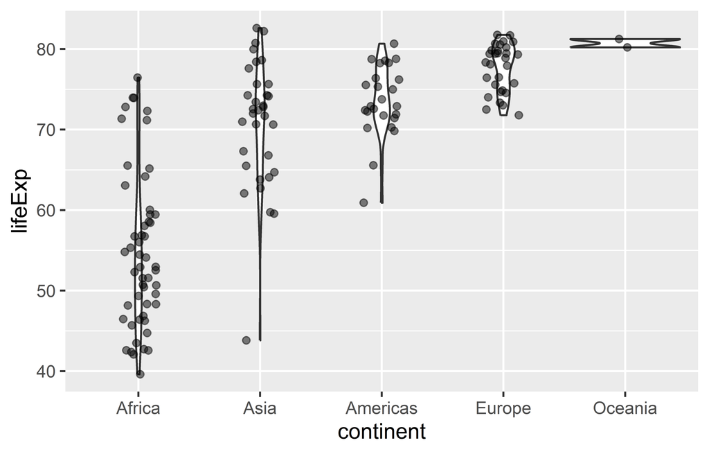

Figure 19: The same data as a violin plot: each shape is a density plot mirrored on its axis, so Africa’s wide spread and Europe’s tight cluster are visible at a glance.

```r
set.seed(2026) # jitter is random

gapminder_2007 |>
  mutate(
    continent = fct_reorder(continent, lifeExp)
  ) |>
  ggplot(aes(x = continent, y = lifeExp)) +
  geom_violin() +
  geom_jitter(width = 0.15, alpha = 0.5)
```

One line changed. A violin shows the **whole shape** of each distribution, a box only five numbers.

## Over time: line plot

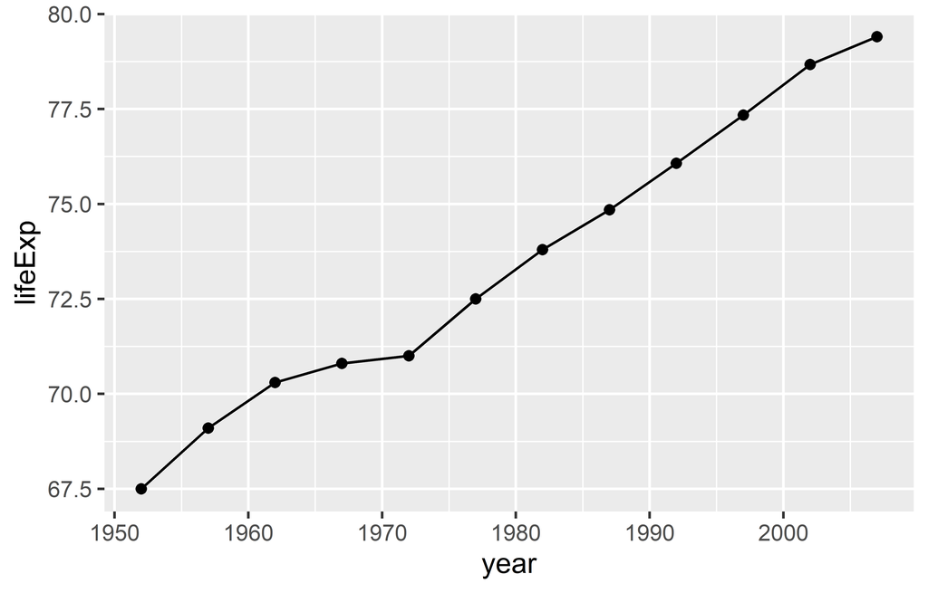

Figure 20: Life expectancy in Germany, 1952 to 2007: a steady rise of about 12 years over 55 years.

```r
gapminder |>
  filter(country == "Germany") |>
  ggplot(aes(x = year, y = lifeExp)) +
  geom_line() +
  geom_point()
```

- `geom_line()` connects the points **in the order of x**.
- The points mark where the data are, which matters with only twelve years.
- For **many** countries, add `group = country` to `aes()`, or ggplot joins them all into one zigzag.

## Practice: two variables

**Do this now.**

1. A box plot of GDP per capita by continent in 2007, ordered by the median, with every country as a point on top.
2. A line plot of life expectancy in Germany over time.
3. **Stretch:** Germany and Rwanda in one plot, one line each. Hint: `%in%` and `colour = country`. What happened in Rwanda?

## Practice: two variables, solution

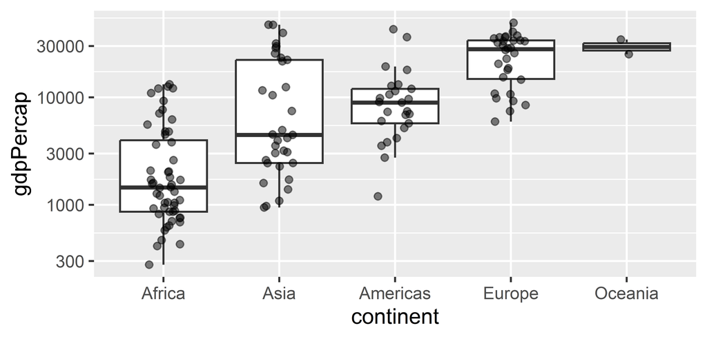

Figure 21: GDP per capita by continent in 2007, on a log scale and ordered by the median.

```r
set.seed(2026)

gapminder_2007 |>
  mutate(
    continent = fct_reorder(continent, gdpPercap)
  ) |>
  ggplot(aes(x = continent, y = gdpPercap)) +
  geom_boxplot(outliers = FALSE) +
  geom_jitter(width = 0.15, alpha = 0.5) +
  scale_y_log10()
```

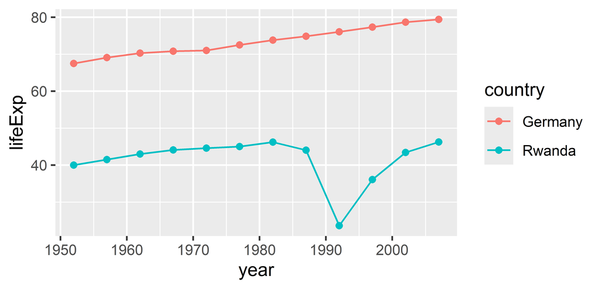

Figure 22: Life expectancy in Germany and Rwanda. Rwanda’s falls to 24 years in 1992, during the civil war and genocide.

```r
gapminder |>
  filter(country %in% c("Germany", "Rwanda")) |>
  ggplot(aes(x = year, y = lifeExp,
             colour = country)) +
  geom_line() +
  geom_point()
```

# Three and more variables

## More aesthetics: colour and size

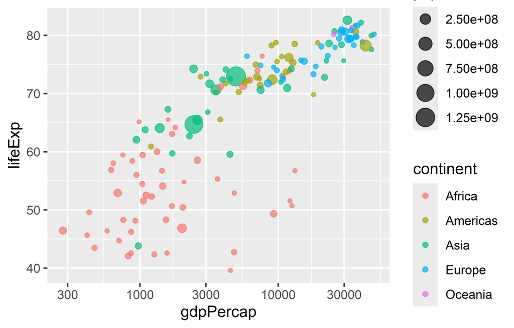

Figure 23: Our running example with continent as colour and population as point size: the large Asian countries sit in the middle of the income range.

```r
gapminder_2007 |>
  ggplot(aes(x = gdpPercap, y = lifeExp,
             colour = continent, size = pop)) +
  geom_point(alpha = 0.7) +
  scale_x_log10()
```

Four variables in one figure: two positions, a colour and a size. This is Hans Rosling’s famous chart.

## Which aesthetic for which variable?

Table 6: The main aesthetics of `ggplot2` and the kind of variable each one suits. Inside `aes()` an aesthetic is mapped to a variable, outside it is a fixed value.

| Aesthetic | What it changes | Suits |
| --- | --- | --- |
| `x`, `y` | Position | Any variable, and the most precise encoding |
| `colour` | Colour of points and lines | Categories, or a numeric scale |
| `fill` | Colour inside bars, boxes, areas | Categories, or a numeric scale |
| `size` | Point size, line width | Numeric |
| `shape` | Point shape | A few categories, at most about six |
| `linetype` | Solid, dashed, dotted | A few categories |
| `alpha` | Transparency | Mostly fixed, against overplotting |

**Note**

**`colour` or `color`?** `ggplot2` accepts both spellings. This course writes `colour`.

## Redundant encoding

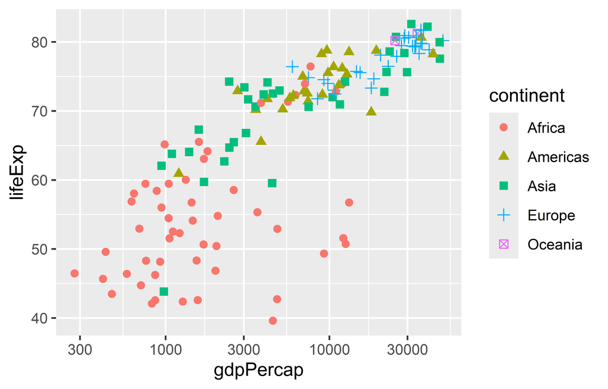

Figure 24: Continent mapped to both colour and shape: the groups stay distinct for colourblind readers and in a black and white print.

```r
gapminder_2007 |>
  ggplot(aes(x = gdpPercap, y = lifeExp,
             colour = continent,
             shape = continent)) +
  geom_point(size = 2) +
  scale_x_log10()
```

- About **1 in 12 men** has a red-green colour vision deficiency.
- Encode an important variable **twice**, so colour is never the only cue.
- Both mapped to one variable: `ggplot2` merges them into one legend.

## Small multiples: `facet_wrap()`

```r
gapminder_2007 |>
  ggplot(aes(x = gdpPercap, y = lifeExp)) +
  geom_point(alpha = 0.5) +
  scale_x_log10() +
  facet_wrap(~continent, nrow = 1)
```

[figure not shown]

Figure 25: Our running example split into one panel per continent. All panels share the same axes, so the positions can be compared across continents.

**Tip**

**Keep the scales fixed unless you have a reason.** `facet_wrap(~continent, scales = "free")` gives each panel its own axes, which shows detail within a panel but breaks every comparison across panels.

## Practice: many variables

**Do this now.**

1. Plot life expectancy over time for **every** country, one line per country. Use `group = country` and a low `alpha`.
2. Split the plot into one panel per continent.
3. **Stretch:** draw Rwanda on top in orange (`colour = "#E07B39"`). Hint: a second `geom_line()` with its own `data =`.

## Practice: many variables, solution

```r
gapminder |>
  ggplot(aes(x = year, y = lifeExp, group = country)) +
  geom_line(alpha = 0.3) +
  geom_line(
    data = filter(gapminder, country == "Rwanda"),
    colour = "#E07B39",
    linewidth = 1
  ) + # stretch
  facet_wrap(~continent, nrow = 1)
```

[figure not shown]

Figure 26: Life expectancy over time for all 142 countries, one panel per continent, with Rwanda in orange. Nearly every line rises, and the dips in Africa stand out.

Grey context plus one highlighted line answers the question every figure must answer: **compared to what?**

# Styling: less ink, more information

## Tufte: the data-ink ratio

> Above all else show the data.

> Edward Tufte (1983)

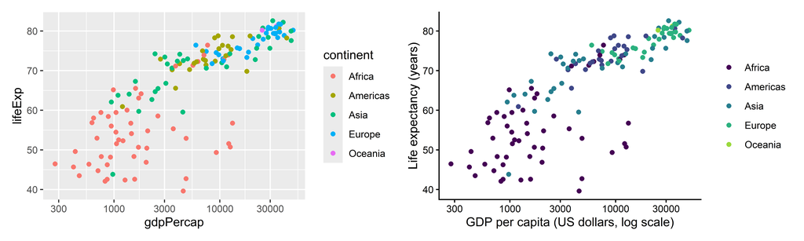

Figure 27: The same data twice. Left, the default: grey panel, white grid, a legend to decode. Right, the background and minor grid are gone and the axes say what they show.

**Data-ink** is the ink that shows data. Every other mark has to earn its place: remove what carries no information, and make deliberate choices about what stays.

## Labels that say something

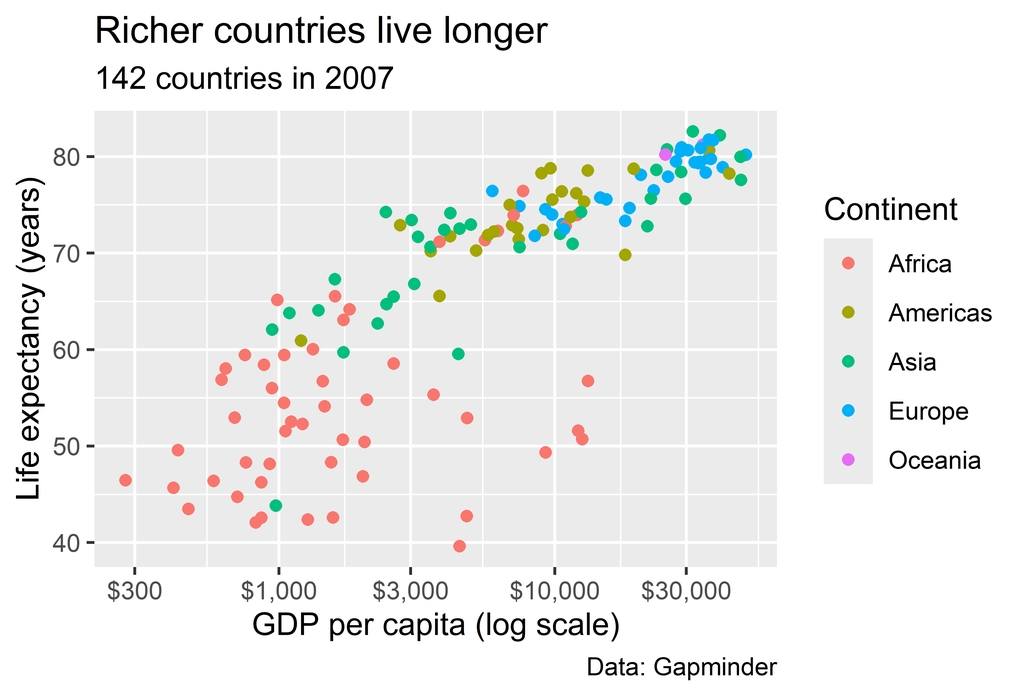

Figure 28: Our running example with a title that states the finding, axis titles with units, a source caption and a readable legend title.

```r
gapminder_2007 |>
  ggplot(aes(x = gdpPercap, y = lifeExp,
             colour = continent)) +
  geom_point() +
  scale_x_log10(
    labels = scales::label_dollar(accuracy = 1)
  ) +
  labs(
    title = "Richer countries live longer",
    subtitle = "142 countries in 2007",
    x = "GDP per capita (log scale)",
    y = "Life expectancy (years)",
    colour = "Continent",
    caption = "Data: Gapminder"
  )
```

- The **title states the finding**, the subtitle says what is shown.
- Axis titles carry **units**, the caption names the **source**.
- `scales::label_dollar()` and friends format axis numbers.

## Themes: the non-data ink

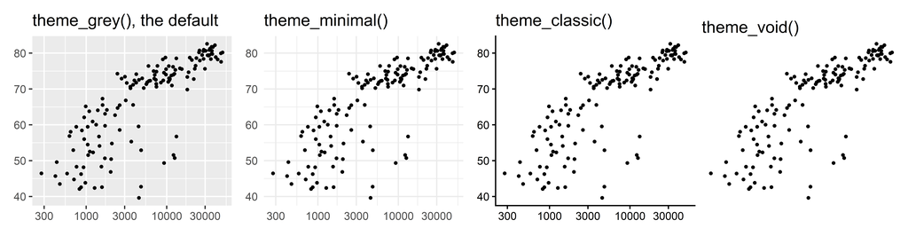

Figure 29: One plot in four built-in themes. theme_minimal() and theme_classic() remove the most non-data ink, theme_void() removes even the axes.

A complete theme first, then `theme()` for single tweaks:

```r
# ... the rest of the plot, then:
theme_classic(base_size = 14) +
  theme(legend.position = "bottom")
```

`base_size` scales every text element at once.

## Colour with intent

Table 7: Three kinds of colour palette, each matched to a kind of variable. All of these scales are built into `ggplot2`.

| Palette | When | Example | In `ggplot2` |
| --- | --- | --- | --- |
| **Qualitative** | Categories without an order | Continent | `scale_colour_viridis_d()`, `scale_colour_brewer(palette = "Dark2")` |
| **Sequential** | Ordered, from low to high | Life expectancy | `scale_colour_viridis_c()`, `scale_fill_distiller(palette = "Blues")` |
| **Diverging** | Above or below a meaningful midpoint | Change since 1952, around 0 | `scale_fill_distiller(palette = "RdBu")`, `scale_colour_gradient2()` |

**Warning**

**Never let red against green carry a distinction.** It is the pair colourblind readers confuse most. The viridis palettes stay distinct for most colour vision deficiencies and in greyscale.

## Annotate what matters

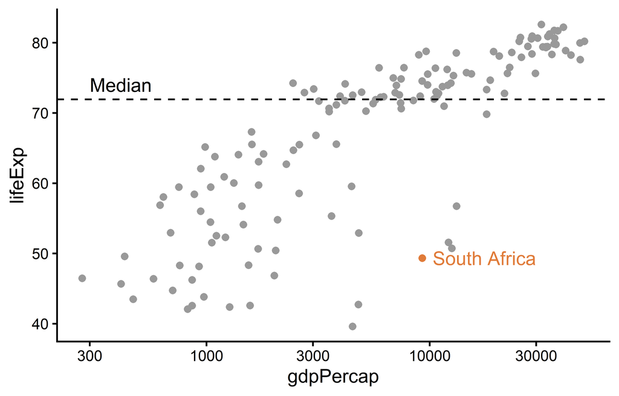

Figure 30: A reference line at the median life expectancy and one labelled outlier, South Africa.

```r
median_life <- median(gapminder_2007$lifeExp)
south_africa <- gapminder_2007 |>
  filter(country == "South Africa")

gapminder_2007 |>
  ggplot(aes(x = gdpPercap, y = lifeExp)) +
  geom_point(colour = "grey60") +
  geom_hline(yintercept = median_life,
             linetype = "dashed") +
  annotate("text", x = 300, y = 74,
           label = "Median", hjust = 0) +
  geom_point(data = south_africa,
             colour = "#E07B39") +
  geom_text(data = south_africa,
            aes(label = country), colour = "#E07B39",
            hjust = -0.1) +
  scale_x_log10() +
  theme_classic()
```

`annotate()` adds a mark that is not in the data, `geom_text()` labels points from the data. Label **a few** points directly, so the reader need not hunt through a legend.

## The finished figure

**View source**

```r
gapminder_2007 |>
  ggplot(aes(x = gdpPercap, y = lifeExp, colour = continent, size = pop)) +
  geom_point(alpha = 0.7) +
  scale_x_log10(labels = scales::label_dollar(accuracy = 1)) +
  scale_colour_viridis_d(end = 0.85) +
  scale_size(range = c(1, 10), guide = "none") +
  labs(
    title = "Richer countries live longer, with flattening gains",
    subtitle = "142 countries in 2007, point size proportional to population",
    x = "GDP per capita (log scale, inflation-adjusted)",
    y = "Life expectancy (years)",
    colour = NULL,
    caption = "Data: Gapminder, via the gapminder R package"
  ) +
  theme_classic(base_size = 13) +
  theme(legend.position = "top")
```

[figure not shown]

Figure 31: Life expectancy against GDP per capita for 142 countries in 2007. Life expectancy rises with income, steeply among poor countries and slowly among rich ones, and African countries sit below the trend at every income level.

## Practice: make it publication-ready

**Do this now.** Start from your faceted line plot of life expectancy over time.

1. A **title that states a finding**, and a subtitle that says what is shown.
2. Axis titles with **units**, and a caption with the **source**.
3. A built-in theme of your choice, then remove the minor grid lines. Hint: `theme(panel.grid.minor = element_blank())`.
4. **Stretch:** label Rwanda directly instead of explaining the orange line in the caption.

## Practice: publication-ready, solution

```r
gapminder |>
  ggplot(aes(x = year, y = lifeExp, group = country)) +
  geom_line(alpha = 0.3) +
  geom_line(
    data = filter(gapminder, country == "Rwanda"),
    colour = "#E07B39",
    linewidth = 1
  ) +
  geom_text(
    data = filter(gapminder, country == "Rwanda", year == 1992),
    aes(label = country),
    colour = "#E07B39",
    hjust = 1.15
  ) + # stretch
  facet_wrap(~continent, nrow = 1) +
  labs(
    title = "Life expectancy rose almost everywhere, but not without setbacks",
    subtitle = "142 countries, 1952 to 2007, one line per country",
    x = NULL,
    y = "Life expectancy (years)",
    caption = "Data: Gapminder, via the gapminder R package"
  ) +
  theme_minimal() +
  theme(panel.grid.minor = element_blank())
```

## Practice: publication-ready, solution

[figure not shown]

Figure 32: The faceted line plot, styled for a reader: a finding as the title, units on the axes, the source in the caption and no minor grid.

# Common pitfalls: what is wrong here?

## How this works

- Six figures, all built from gapminder, all **deliberately bad**.
- For each: what is wrong, and how would you fix it?
- Talk to your neighbour for a minute, then we reveal.

## Pitfall 1: the 3D pie

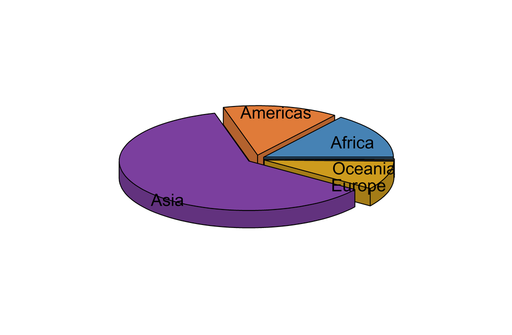

Figure 33: A deliberately bad figure: world population by continent in 2007 as an exploded 3D pie.

**What is wrong, and how would you fix it?**

- **Depth distorts:** the front slices look bigger than the back ones.
- Is Africa larger than the Americas? The pie cannot tell you.
- **Fix:** no 3D, ever, when the data have two dimensions.

## Pitfall 2: the flat pie

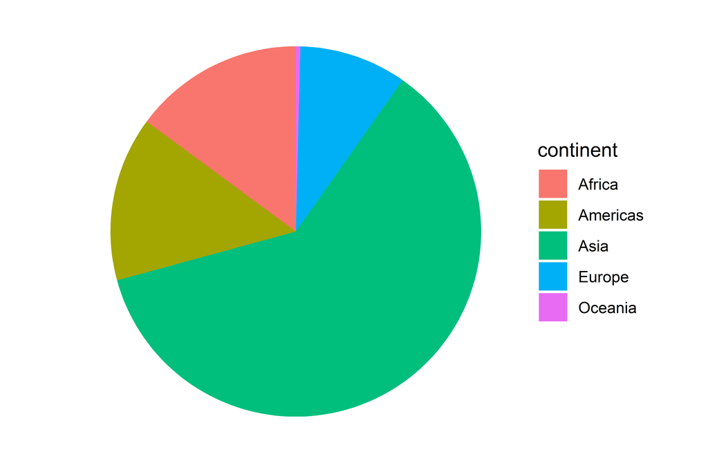

Figure 34: A deliberately bad figure: the same population shares as a flat pie chart.

**What is wrong, and how would you fix it?**

- Better, but we read **angles** poorly, and Africa and the Americas still look equal.
- Comparing two pies, say 1952 and 2007, is harder still.
- **Fix:** turn the slices into bars on a common axis.

## The fix for both pies

**View source**

```r
pop_continent |>
  mutate(continent = fct_reorder(continent, pop_bn)) |>
  ggplot(aes(x = pop_bn, y = continent)) +
  geom_col(fill = "steelblue") +
  labs(
    title = "Asia is home to most of the world's population",
    x = "Population in 2007 (billions)",
    y = NULL,
    caption = "Data: Gapminder"
  ) +
  theme_classic()
```

[figure not shown]

Figure 35: Population by continent in 2007 as sorted horizontal bars: Asia dwarfs the rest, and Africa is slightly ahead of the Americas, which no pie showed.

## Pitfall 3: the truncated axis

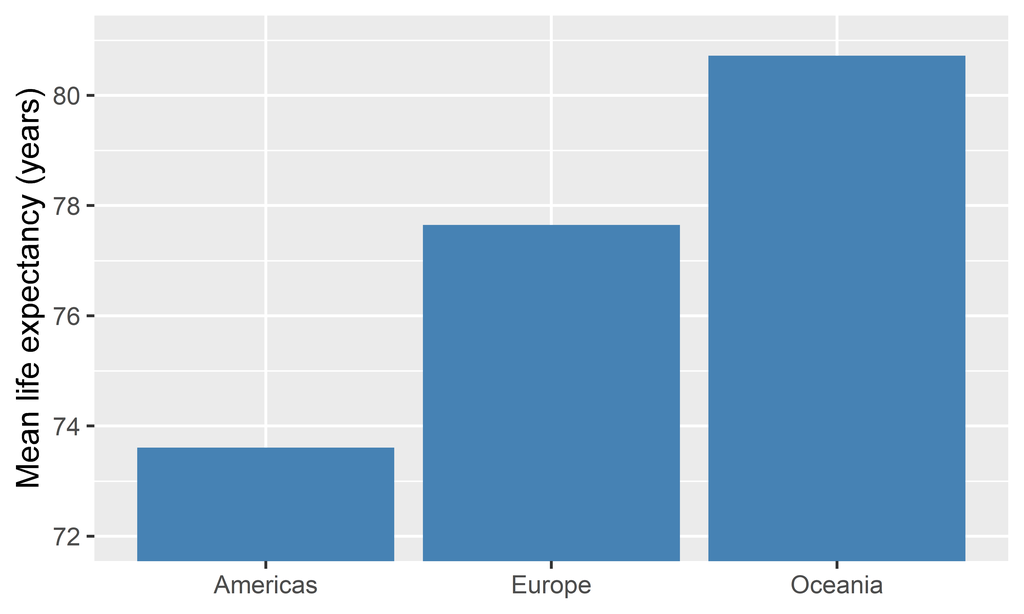

Figure 36: A deliberately bad figure: mean life expectancy in 2007, with the bars cut off at 72 years.

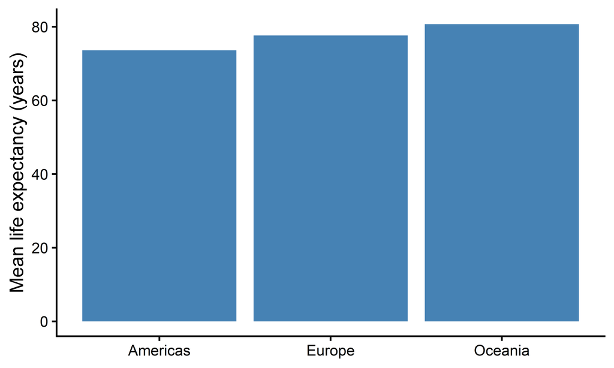

Figure 37: The fix: the same bars from zero. The differences are real, about 7 years, but nowhere near the fivefold gap the cut axis suggested.

A bar shows a value by its **length**, so **bars start at zero**. Points and lines show position, so their axis may zoom in.